# Compare CellRanger vs scUTRquant Clustering - Filtered Genes

# Analysis

## Plot Gene Counts

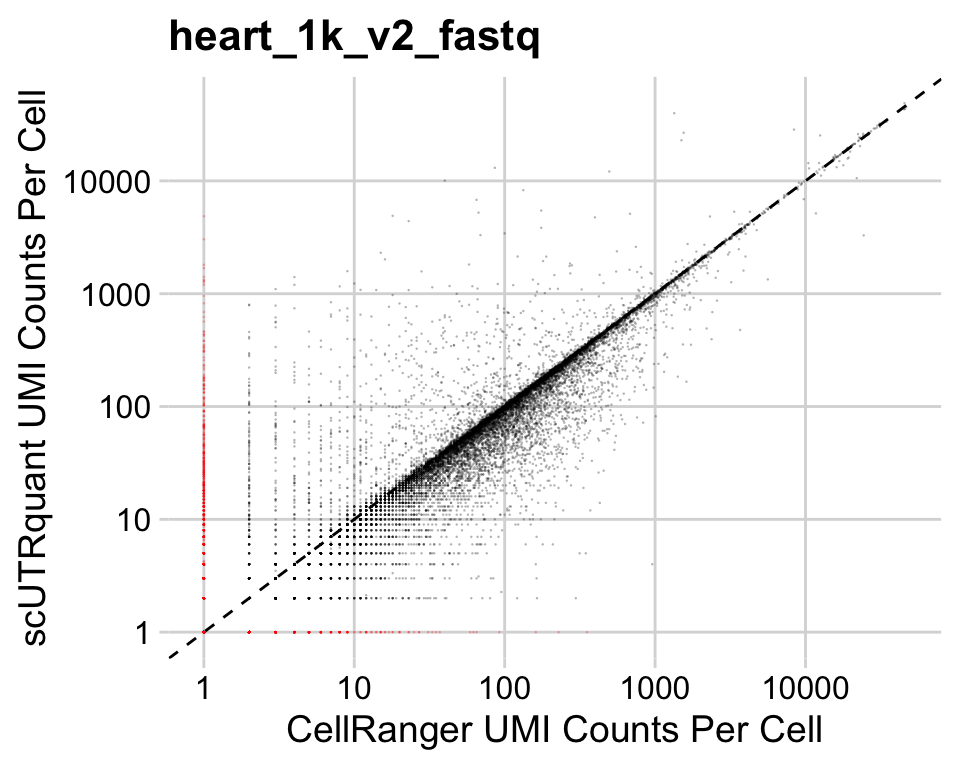

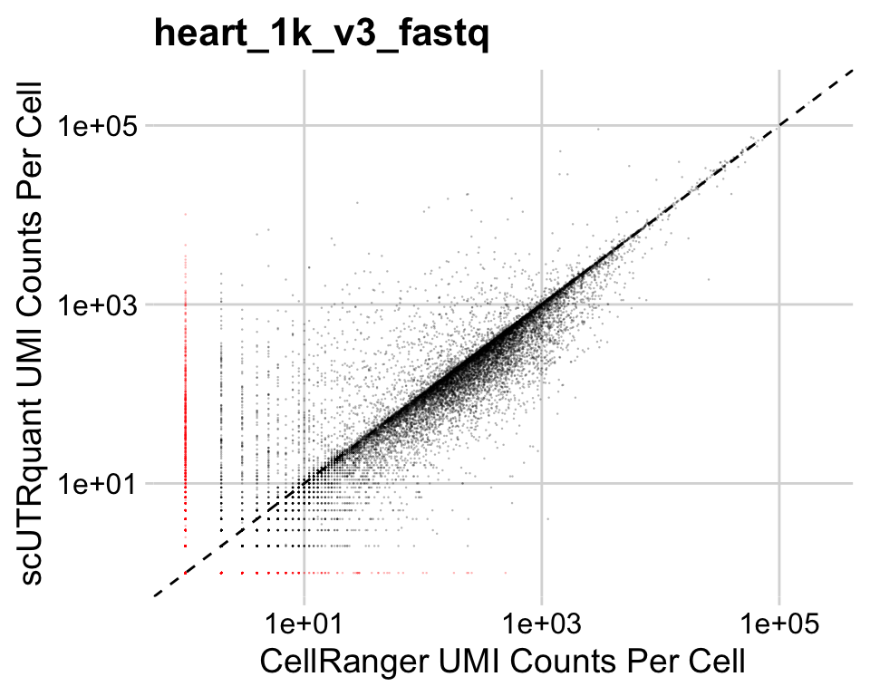

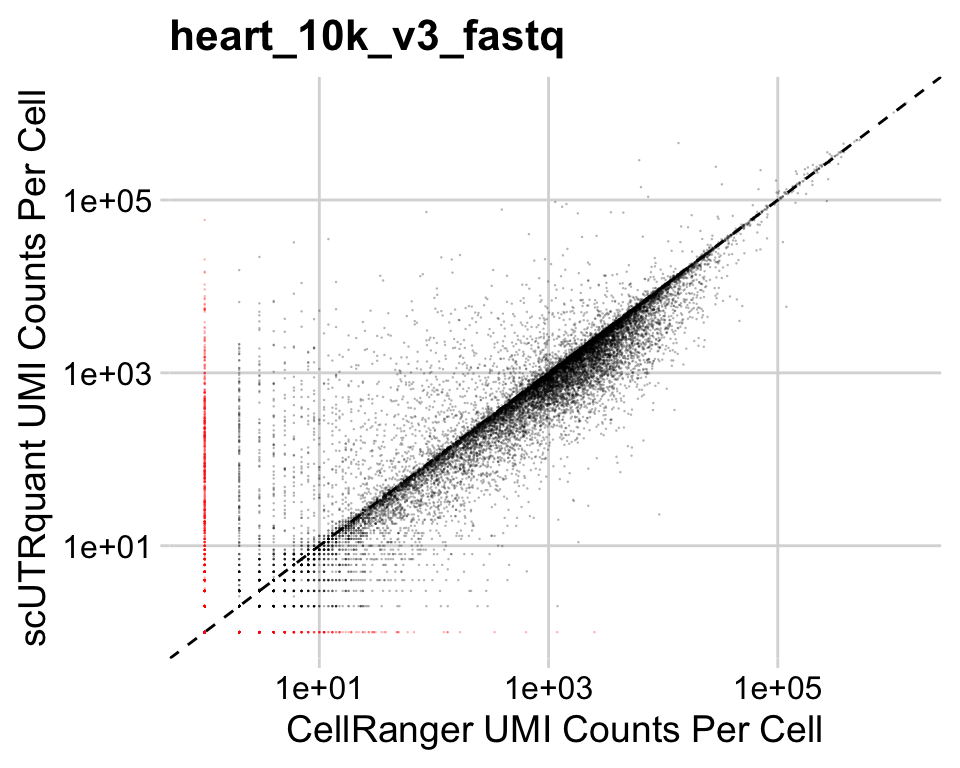

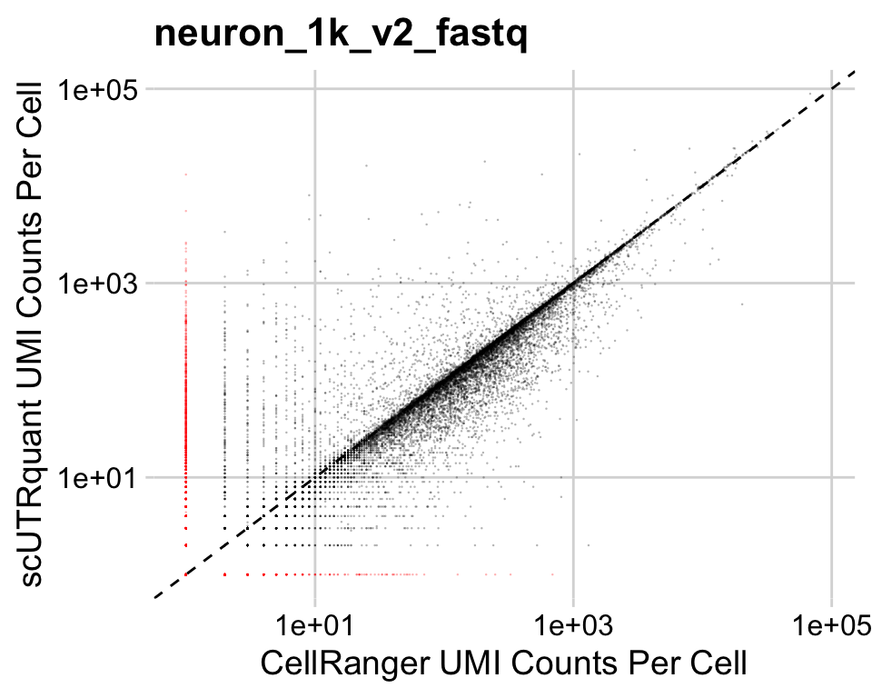

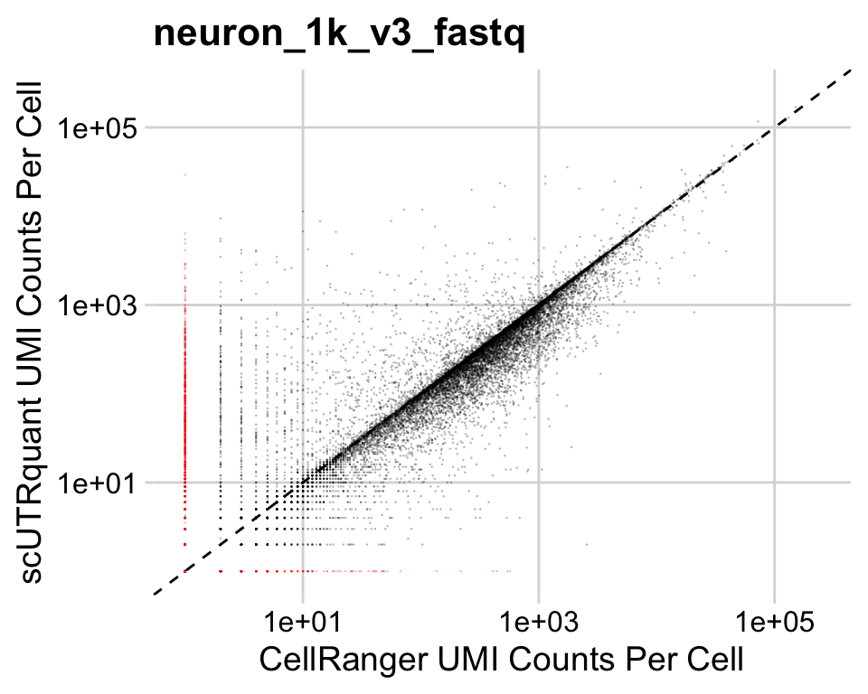

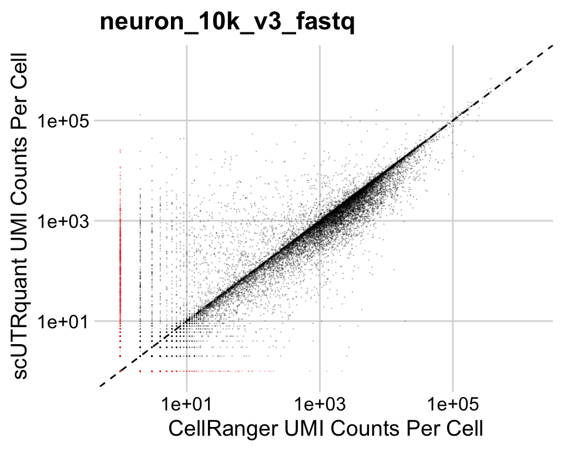

```r
plot_umis_per_gene_compare <- function (sce_x, sce_y, idx,
                                        label_x="CellRanger UMI Counts Per Cell",
                                        label_y="scUTRquant UMI Counts Per Cell") {
  idx_common <- intersect(rownames(sce_x), rownames(sce_y))
  df <- tibble(x=rowSums(counts(sce_x[idx_common,])),
               y=rowSums(counts(sce_y[idx_common,])),
               is_consistent=idx_common %in% idx)

  ggplot(df, aes(x=x+1, y=y+1, color=is_consistent)) +
    geom_point(alpha=0.3, size=0.1, pch=16) +
    geom_abline(slope=1, intercept=0, linetype='dashed') +
    scale_x_log10() + scale_y_log10() +
    scale_color_manual(values=c('red', 'black')) +
    labs(x=label_x, y=label_y) +
    guides(color=FALSE) +
    theme_minimal_grid()
}

df_counts %>%
  transmute(sample_id, g=pmap(list(sce_x=sce_10x, sce_y=sce_sq, idx=idx_genes), plot_umis_per_gene_compare)) %>%
  deframe() %>% {
    for (id in names(.)) {
      ## print locally in this document
      print(.[[id]] + ggtitle(id))

      ## save to PDFs
      # ggsave(sprintf("output/fig1B-umis-per-cell-compare-%s.pdf", id),
      #        .[[id]], width=5, height=4, dpi=300)
    }
  }
```

## Filter Genes and Compute PCA

```r
df_counts %<>%
  mutate(sce_sq=map2(sce_sq, idx_genes, filter_features),
         sce_10x=map2(sce_10x, idx_genes, filter_features)) %>%

  ## add PCA to SCEs
  mutate(sce_sq=map(sce_sq, add_pca),
         sce_10x=map(sce_10x, add_pca))
```

# Clustering

## Louvain

```r
cluster_louvain <- function (sce) {
  clusterRows(reducedDim(sce, "PCA"), NNGraphParam(cluster.fun="louvain"))
}

df_counts %>%
  ## cluster
  mutate(clusters_sq=map(sce_sq, cluster_louvain),
         clusters_10x=map(sce_10x, cluster_louvain)) %>%

  ## compute adjusted Rand index
  transmute(sample_id, n_cells=map_int(idx_cells, length),
            ari=map2_dbl(clusters_sq, clusters_10x, aricode::ARI),
            nmi=map2_dbl(clusters_sq, clusters_10x, aricode::NMI),
            nvi=map2_dbl(clusters_sq, clusters_10x, aricode::NVI)) %>%

  knitr::kable()
```

| sample_id | n_cells | ari | nmi | nvi |
| --- | --- | --- | --- | --- |
| heart_1k_v2_fastq | 529 | 0.7819730 | 0.8753599 | 0.2194445 |
| heart_1k_v3_fastq | 739 | 0.8157099 | 0.8654743 | 0.2202704 |
| heart_10k_v3_fastq | 6214 | 0.6968391 | 0.8016853 | 0.3211700 |
| neuron_1k_v2_fastq | 1080 | 0.5640109 | 0.6525069 | 0.4559194 |
| neuron_1k_v3_fastq | 1199 | 0.5766500 | 0.6925103 | 0.4452745 |
| neuron_10k_v3_fastq | 11371 | 0.4491175 | 0.6240419 | 0.5170094 |